# Brain Tumour MRI Image Classification

# Model Evaluation:

```python
model.compile(optimizer="adam", loss='categorical_crossentropy', metrics=["accuracy"])

callback = tf.keras.callbacks.EarlyStopping(monitor='accuracy', patience=4)

history = model.fit(train_images, validation_data=val_images, epochs=6, callbacks=callback)
```

# A function plot_history is defined to plot the training and validation loss and accuracy over epochs.

```python
def plot_history(history):
    hist = history.history
    hist['epoch'] = history.epoch
    epoch = np.array(hist['epoch'])
    loss=np.array(hist['loss'])
    val_loss=np.array(hist['val_loss'])
    accuracy = np.array(hist['accuracy'])
    val_accuracy = np.array(hist['val_accuracy'])
    plt.figure(figsize=(8,8))

    plt.subplot(2, 2, 1)
    plt.plot(accuracy, label = "Training accuracy")
    plt.plot(val_accuracy, label="Validation accuracy")
    plt.legend()
    plt.title("Training vs validation accuracy")


    plt.subplot(2,2,2)
    plt.plot(loss, label = "Training loss")
    plt.plot(val_loss, label="Validation loss")
    plt.legend()
    plt.title("Training vs validation loss")

    plt.show()
```

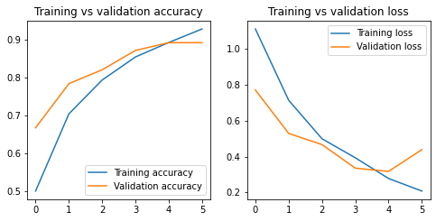

```python
plot_history(history)
```

# The trained model is used to predict the classes of the test images (test_images) and the predictions are converted back into label names.

```python
pred = model.predict(test_images)
pred = np.argmax(pred, axis=1)

labels = train_images.class_indices
labels = dict((v,k) for k, v in labels.items())

print(labels)
print(pred)
```

[output not shown]

# Classification report, confusion matrix, and accuracy of the model on the test set are printed and displayed.

```python
y_pred = [labels[k] for k in pred]
print(classification_report(test_df.Labels, y_pred))
print('--------------------------------')
print(confusion_matrix(test_df.Labels, y_pred))
print('--------------------------------')
```

```
                  precision    recall  f1-score   support

    glioma_tumor       0.83      0.84      0.84       148
meningioma_tumor       0.89      0.80      0.84       187
        no_tumor       0.90      0.94      0.92        98
 pituitary_tumor       0.90      0.99      0.95       143

        accuracy                           0.88       576
       macro avg       0.88      0.89      0.89       576
    weighted avg       0.88      0.88      0.88       576

--------------------------------
[[125  14   4   5]
 [ 23 149   6   9]
 [  1   4  92   1]
 [  1   0   0 142]]
--------------------------------
```

```python
model.evaluate(test_images)[1]
```

```
0.8819444179534912
```

# Preprocessing the image and Making predictions:

```python
model.save('E:\TGushpu\Brain Tumor MRI Classfication/BrainTumor.h5')
```

```python
model = tf.keras.models.load_model('E:\TGushpu\Brain Tumor MRI Classfication/braintumor.h5')
```

```python
image_path = r"E:\TGushpu\Brain Tumor MRI Classfication\Testing\no_tumor\image(1).jpg"
image = cv2.imread(image_path)
image = cv2.resize(image, (512, 512))
image = cv2.cvtColor(image, cv2.COLOR_BGR2RGB)
image = np.expand_dims(image, axis=0)
```

- Resize the image to match the input shape of the model
- Convert BGR to RGB
- Add a batch dimension

```python
image = tf.keras.applications.mobilenet_v2.preprocess_input(image)
```

```python
predictions = model.predict(image)
predicted_class = np.argmax(predictions[0])
prediction_percentage = np.max(predictions[0]) * 100
```

```python
labels = {0: 'glioma_tumor', 1: 'meningioma_tumor', 2: 'no_tumor', 3: 'pituitary_tumor'}
predicted_label = labels[predicted_class]
print('Predicted Label:', predicted_label)
print('Prediction Percentage: {:.2f}%'.format(prediction_percentage))
```

```
Predicted Label: no_tumor
Prediction Percentage: 99.92%
```

```
Clipping input data to the valid range for imshow with RGB data ([0..1] for floats or [0..255] for integers).
```

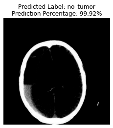

```python
plt.imshow(image[0])
plt.title('Predicted Label: {}\nPrediction Percentage: {:.2f}%'.format(predicted_label, prediction_percentage))
plt.axis('off')
plt.show()
```

# No_tumor

```python
image_path = r"E:\TGushpu\Brain Tumor MRI Classfication\Testing\no_tumor\image(10).jpg"
image = cv2.imread(image_path)
image = cv2.resize(image, (512, 512))
image = cv2.cvtColor(image, cv2.COLOR_BGR2RGB)
image = np.expand_dims(image, axis=0)
```

```python
image = tf.keras.applications.mobilenet_v2.preprocess_input(image)
```

```python
# Make predictions
predictions = model.predict(image)
predicted_class = np.argmax(predictions[0])
prediction_percentage = np.max(predictions[0]) * 100
```

```python
labels = {0: 'glioma_tumor', 1: 'meningioma_tumor', 2: 'no_tumor', 3: 'pituitary_tumor'}
predicted_label = labels[predicted_class]
print('Predicted Label:', predicted_label)
print('Prediction Percentage: {:.2f}%'.format(prediction_percentage))
```

```
Predicted Label: no_tumor
Prediction Percentage: 100.00%
```

```
Clipping input data to the valid range for imshow with RGB data ([0..1] for floats or [0..255] for integers).
```

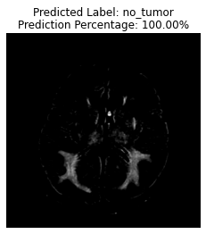

```python
plt.imshow(image[0])
plt.title('Predicted Label: {}\nPrediction Percentage: {:.2f}%'.format(predicted_label, prediction_percentage))
plt.axis('off')
plt.show()
```

# Meningioma_tumor

```python
image_path = r"E:\TGushpu\Brain Tumor MRI Classfication\Testing\meningioma_tumor\image(25).jpg"
image = cv2.imread(image_path)
image = cv2.resize(image, (512, 512))
image = cv2.cvtColor(image, cv2.COLOR_BGR2RGB)
image = np.expand_dims(image, axis=0)

image = tf.keras.applications.mobilenet_v2.preprocess_input(image)

predictions = model.predict(image)
predicted_class = np.argmax(predictions[0])
prediction_percentage = np.max(predictions[0]) * 100

labels = {0: 'glioma_tumor', 1: 'meningioma_tumor', 2: 'no_tumor', 3: 'pituitary_tumor'}
predicted_label = labels[predicted_class]
print('Predicted Label:', predicted_label)
print('Prediction Percentage: {:.2f}%'.format(prediction_percentage))
```

```
Predicted Label: meningioma_tumor
Prediction Percentage: 100.00%
```

# Pituitary_tumor

```python
image_path = r"E:\TGushpu\Brain Tumor MRI Classfication\Testing\pituitary_tumor\image(1).jpg"
image = cv2.imread(image_path)
image = cv2.resize(image, (512, 512))
image = cv2.cvtColor(image, cv2.COLOR_BGR2RGB)
image = np.expand_dims(image, axis=0)

image = tf.keras.applications.mobilenet_v2.preprocess_input(image)

predictions = model.predict(image)
predicted_class = np.argmax(predictions[0])
prediction_percentage = np.max(predictions[0]) * 100

labels = {0: 'glioma_tumor', 1: 'meningioma_tumor', 2: 'no_tumor', 3: 'pituitary_tumor'}
predicted_label = labels[predicted_class]
print('Predicted Label:', predicted_label)
print('Prediction Percentage: {:.2f}%'.format(prediction_percentage))
```

```
Predicted Label: pituitary_tumor
Prediction Percentage: 100.00%
```

# Glioma_tumor

```python
image_path = r"E:\TGushpu\Brain Tumor MRI Classfication\Testing\glioma_tumor\image(1).jpg"
image = cv2.imread(image_path)
image = cv2.resize(image, (512, 512))
image = cv2.cvtColor(image, cv2.COLOR_BGR2RGB)
image = np.expand_dims(image, axis=0)

image = tf.keras.applications.mobilenet_v2.preprocess_input(image)

predictions = model.predict(image)
predicted_class = np.argmax(predictions[0])
prediction_percentage = np.max(predictions[0]) * 100

labels = {0: 'glioma_tumor', 1: 'meningioma_tumor', 2: 'no_tumor', 3: 'pituitary_tumor'}
predicted_label = labels[predicted_class]
print('Predicted Label:', predicted_label)
print('Prediction Percentage: {:.2f}%'.format(prediction_percentage))
```

```
Predicted Label: glioma_tumor
Prediction Percentage: 99.40%
```